# Split-ORF Report

14 April 2021

This report shows a number of summary statistics of the a result file obtained from the SplitOrfs software.

## Overview of the valid alignment results:

```
##                                       Entry Values
## 1                     Number of transcripts  31817
## 2                Transcripts with >= 2 ORFs   7056
## 3 Transcripts with >= 1 PFAM domain overlap   3514
## 4                    Number of unique Genes   3911
```

## Histogramm of matching ORFs per transcripts:

[output not shown]

[output cut: 279 more lines]

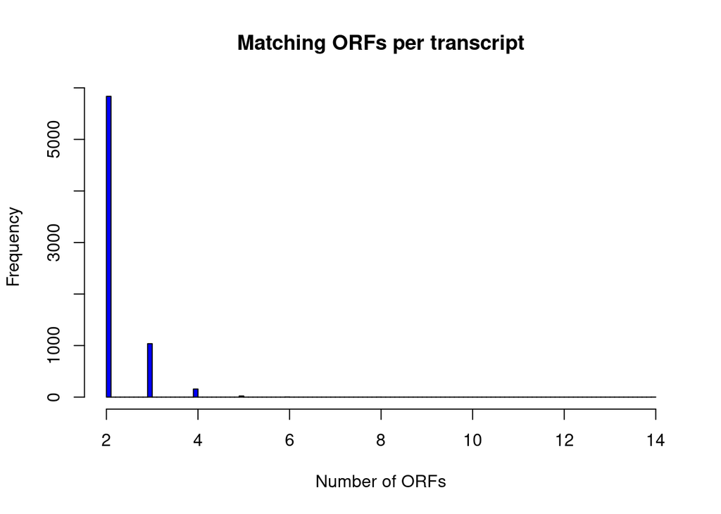

## Histogramm of NMD-protein pairs

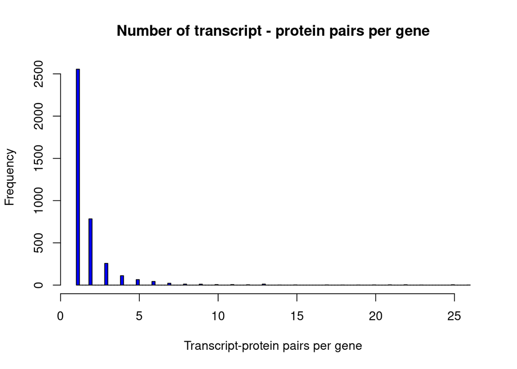

## Top 20 genes, that have the most transcripts with >=2 ORFs

```
##              geneIDs frequency
## 352  ENSG00000075413        26
## 730  ENSG00000103811        25
## 1118 ENSG00000115525        25
## 1320 ENSG00000124155        25
## 1366 ENSG00000126091        25
## 1186 ENSG00000118513        23
## 940  ENSG00000109654        22
## 1508 ENSG00000131778        22
## 2076 ENSG00000148356        22
## 3398 ENSG00000197912        22
## 32   ENSG00000006071        21
## 520  ENSG00000092108        21
## 1018 ENSG00000112367        21
## 1087 ENSG00000114786        20
## 2315 ENSG00000158864        20
## 2513 ENSG00000164073        19
## 3870 ENSG00000284770        18
## 737  ENSG00000104218        17
## 934  ENSG00000109339        17
## 504  ENSG00000090861        15
```

## Histogramm of min and max sequence identity

A histogramm of min and max sequence identity values from the ORF-protein alignments, i.e., each such value is derived from one ORF-protein alignment. For all ORFs of a protein-ORF match the min respectively max seq. identity is recorded. The minimal sequence identity allowed for an alignment by default is 95%.

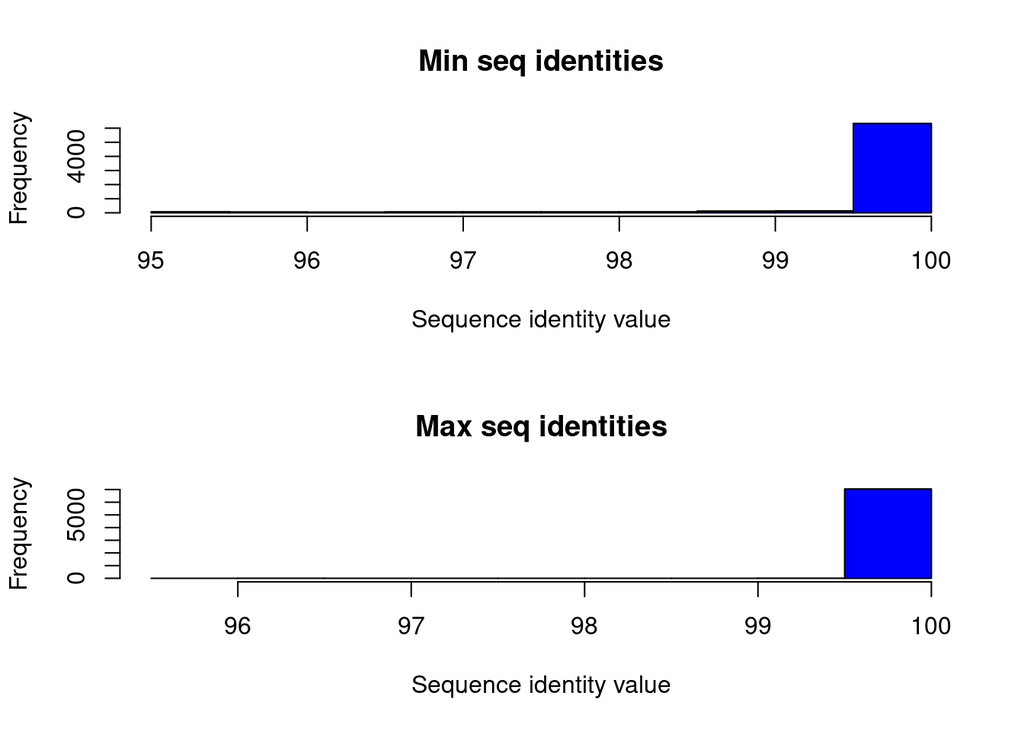

## Histogram in the intervall [0,2000]

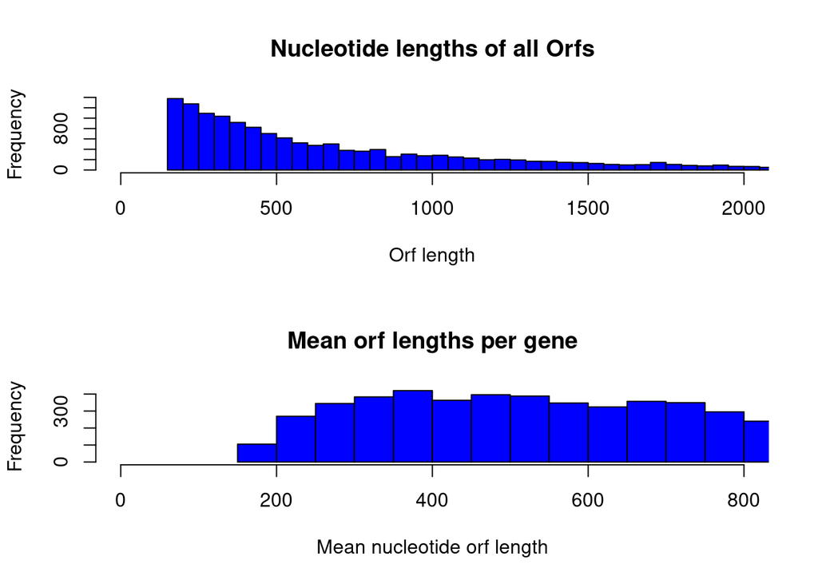

## PFAM domain annotations

PFAM domain annotations were obtained for all protein coding genes. Here we show how often more than one ORF overlaps an annotated PFAM domain in the alignment region. For example a value of two means, that two distinct ORFs made from the transcript aligned to regions in the protein that overlapped PFAM annotations.

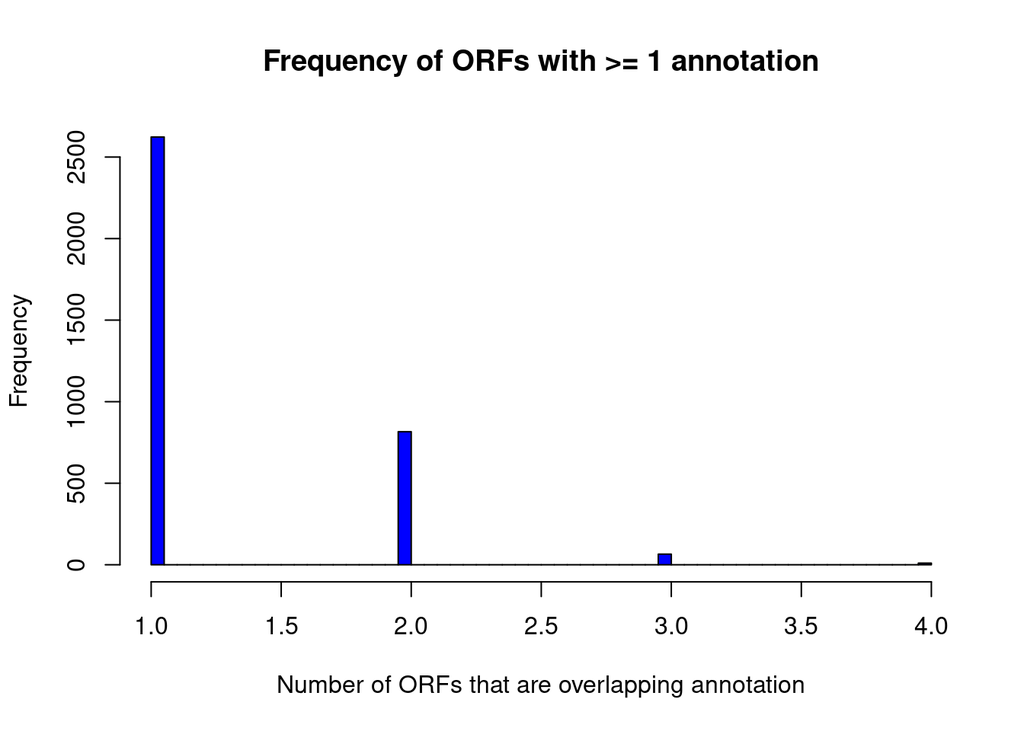

## Top 20 genes that have the most transcripts ORFs with annotations per transcript

```
##               geneID      OrfTransID NumORFAnnot
## 996  ENSG00000249715 ENST00000436930           4
## 2343 ENSG00000163531 ENST00000504476           4
## 2732 ENSG00000169398 ENST00000519993           4
## 3111 ENSG00000130270 ENST00000531925           4
## 4698 ENSG00000151150 ENST00000622427           4
## 4950 ENSG00000198838 ENST00000635790           4
## 5204 ENSG00000156113 ENST00000639968           4
## 6005 ENSG00000077522 ENST00000652096           4
## 6137 ENSG00000075711 ENST00000670366           4
## 6227 ENSG00000251322 ENST00000673971           4
## 177  ENSG00000171509 ENST00000342048           3
## 264  ENSG00000118513 ENST00000367812           3
## 299  ENSG00000150275 ENST00000373956           3
## 331  ENSG00000089091 ENST00000377630           3
```

[output cut: 27 more lines]

## Domain analysis

Number of different Domain annotations found in Split ORFs.

```
## [1] 1635
```

Analysis of the type of domains that are part of SplitORFs looking per gene, this avoids counting similar transcripts from the same gene.

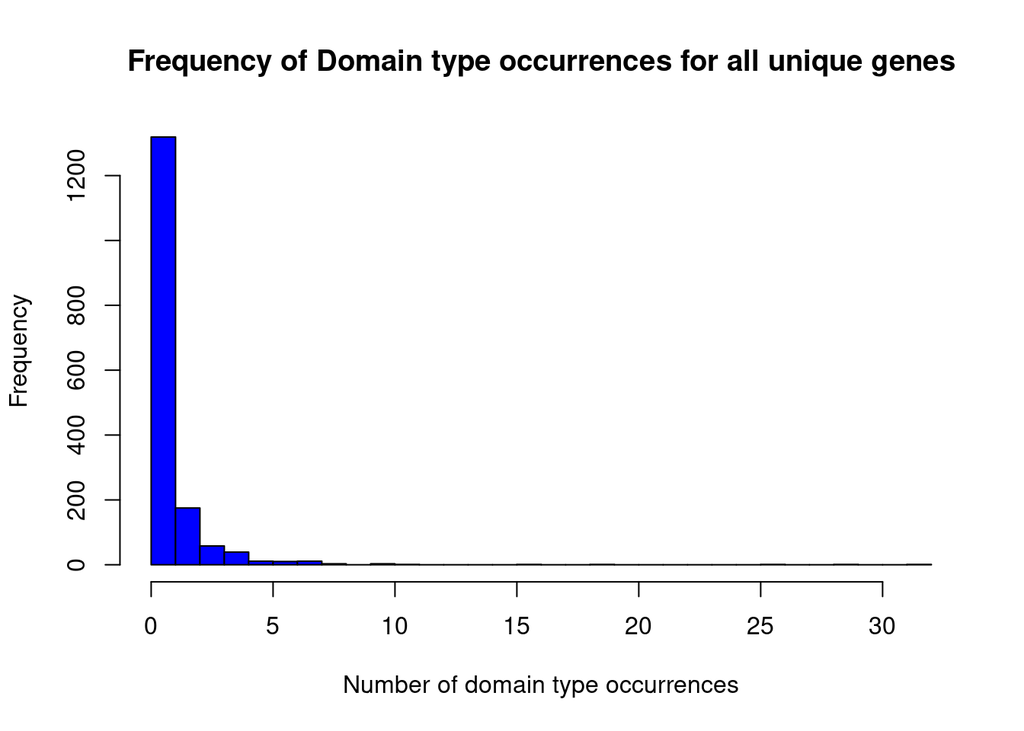

Show the top 50 most frequent domains found in Split Orfs (counting once per gene).

```
##
##         PF00400         PF00076         PF00096         PF00069         PF12796
##              32              29              26              19              16
##         PF00271         PF00105         PF00168         PF02932         PF00412
##              11              10              10              10               8
## PF02023,PF00096         PF07714         PF00046         PF00094         PF00169
##               8               8               7               7               7
## PF00400,PF00400         PF00536         PF00595         PF02793 PF07654,PF07654
##               7               7               7               7               7
##         PF07686         PF13927         PF14604         PF00004         PF00018
##               7               7               7               6               6
## PF00076,PF00076 PF00096,PF01352         PF00134         PF00153 PF00520,PF00520
##               6               6               6               6               6
##         PF00571         PF13499         PF13895         PF00005 PF00153,PF00153
##               6               6               6               5               5
##         PF00520 PF00595,PF00595         PF06623 PF07645,PF07645         PF07654
##               5               5               5               5               5
##         PF08081         PF13516         PF13620         PF17035         PF00010
##               5               5               5               5               4
##         PF00013         PF00027         PF00047 PF00096,PF00096         PF00102
##               4               4               4               4               4
```

Analysis of the type of domains that are part of SplitORFs looking at all transcripts, this incorporates also the case that two transcripts may come from the same gene.

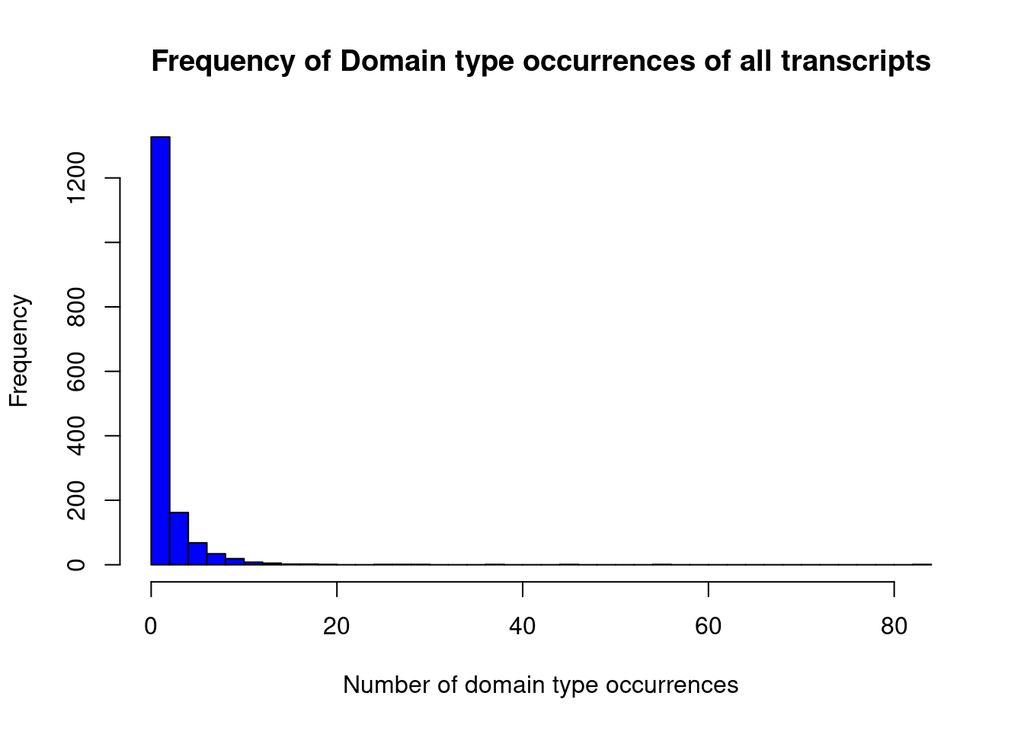

Show the top 50 most frequent domains found in Split Orfs (counting all transcripts).

```
##
##         PF00094         PF00400         PF00076         PF00096         PF00271
##              83              56              46              37              29
##         PF00069         PF12796         PF00777         PF00520         PF02932
##              27              25              20              18              17
##         PF00004         PF00168         PF00105         PF12052         PF00169
##              15              15              14              14              13
##         PF02020         PF07988         PF00531 PF01302,PF14560         PF02149
##              13              13              12              12              12
##         PF07714         PF13516 PF00400,PF00400 PF04113,PF04113         PF14604
##              12              12              11              11              11
##         PF00005         PF00018         PF00270         PF00412         PF00595
##              10              10              10              10              10
##         PF02770         PF13620         PF13927         PF00035         PF00046
##              10              10              10               9               9
## PF00076,PF00076 PF00520,PF00520         PF00536         PF00571         PF02893
##               9               9               9               9               9
##         PF04991         PF06119         PF07690         PF13895 PF00035,PF00035
##               9               9               9               9               8
##         PF00153         PF00176         PF00249         PF00350         PF01399
##               8               8               8               8               8
```

This document was created with R Markdown and the Knit package. Markdown is a simple formatting syntax for authoring HTML, PDF, and MS Word documents. For more details on using R Markdown see http://rmarkdown.rstudio.com.